# Answer key for HW5 CDA

TA刘丽蓉

2019年12月13日

```r
library(icda)
library(ROCR)
library(ResourceSelection)
library(reshape2)
library(dplyr)
library(stringr)
```

> GDS5037 (20 points)
1. (8 points)

```r
data=read.csv('C:\\Users\\liulirong\\Desktop\\CDA本科助教\\GDS5037\\GDS5037.csv',encoding='UTF-8',header=TRUE)
patients=data[51:158,1] %>% as.character()
keys="MMA|control|SA"
patients_status=patients %>% str_extract(keys)
status=ifelse(patients_status=='control',0,1) %>% as.integer()
```

```r
aics=c()
for(i in 161:41160){
  model=glm(status~as.numeric(t(data[i,3:110])),family=binomial(link='logit'))
  aics=append(aics,model$aic)
}
index=order(aics)[1:10]+160
identifier_name=data[index,2]
for(i in index){
  print(glm(status~as.numeric(t(data[i,3:110])),family=binomial(link='logit')))
}
```

```
##
## Call:  glm(formula = status ~ as.numeric(t(data[i, 3:110])), family = binomial(link = "logit"))
##
## Coefficients:
##                   (Intercept)  as.numeric(t(data[i, 3:110]))
##                        41.730                         -4.533
##
## Degrees of Freedom: 107 Total (i.e. Null);  106 Residual
## Null Deviance:       103.5
## Residual Deviance: 69.69     AIC: 73.69
##
## Call:  glm(formula = status ~ as.numeric(t(data[i, 3:110])), family = binomial(link = "logit"))
##
## Coefficients:
##                   (Intercept)  as.numeric(t(data[i, 3:110]))
##                       -46.002                          4.935
##
## Degrees of Freedom: 107 Total (i.e. Null);  106 Residual
## Null Deviance:       103.5
## Residual Deviance: 69.8  AIC: 73.8
##
## Call:  glm(formula = status ~ as.numeric(t(data[i, 3:110])), family = binomial(link = "logit"))
##
## Coefficients:
##                   (Intercept)  as.numeric(t(data[i, 3:110]))
##                        21.088                         -2.313
##
## Degrees of Freedom: 107 Total (i.e. Null);  106 Residual
## Null Deviance:       103.5
## Residual Deviance: 71.36     AIC: 75.36
##
## Call:  glm(formula = status ~ as.numeric(t(data[i, 3:110])), family = binomial(link = "logit"))
##
## Coefficients:
##                   (Intercept)  as.numeric(t(data[i, 3:110]))
##                       -18.325                          3.817
##
## Degrees of Freedom: 107 Total (i.e. Null);  106 Residual
## Null Deviance:       103.5
## Residual Deviance: 73.13     AIC: 77.13
```

[output cut: 45 more lines]

```
##                       -18.775                          2.992
##
## Degrees of Freedom: 107 Total (i.e. Null);  106 Residual
## Null Deviance:       103.5
## Residual Deviance: 76.9  AIC: 80.9
##
## Call:  glm(formula = status ~ as.numeric(t(data[i, 3:110])), family = binomial(link = "logit"))
##
## Coefficients:
##                   (Intercept)  as.numeric(t(data[i, 3:110]))
##                        20.803                         -1.968
##
## Degrees of Freedom: 107 Total (i.e. Null);  106 Residual
## Null Deviance:       103.5
## Residual Deviance: 76.99     AIC: 80.99
```

2. (6 points)

```r
Temp_data=c()
for(i in index){
  Temp_data=cbind(Temp_data,as.numeric(t(data[i,3:110])))
}
colnames(Temp_data)=identifier_name
cor(Temp_data)
```

```
##                    PER2     DNAJC1 A_32_P171253   AK125351 A_32_P210622
## PER2          1.0000000 -0.5812946    0.5526000 -0.4539717    0.3739600
## DNAJC1       -0.5812946  1.0000000   -0.4292245  0.5712483   -0.4538318
## A_32_P171253  0.5526000 -0.4292245    1.0000000 -0.4932816    0.5735939
## AK125351     -0.4539717  0.5712483   -0.4932816  1.0000000   -0.4572366
## A_32_P210622  0.3739600 -0.4538318    0.5735939 -0.4572366    1.0000000
## TLL1          0.3293344 -0.5094303    0.2940447 -0.3630658    0.3761307
## NAV2          0.5007669 -0.3667723    0.5453714 -0.4309947    0.3935802
## WDR72        -0.2864695  0.5679671   -0.2966637  0.4399657   -0.2579917
## KCNK6        -0.6171761  0.7240860   -0.3931232  0.6977452   -0.4274461
## SLAMF7        0.3161503 -0.4779186    0.2798746 -0.3473009    0.2254454
##                    TLL1       NAV2      WDR72      KCNK6     SLAMF7
## PER2          0.3293344  0.5007669 -0.2864695 -0.6171761  0.3161503
## DNAJC1       -0.5094303 -0.3667723  0.5679671  0.7240860 -0.4779186
## A_32_P171253  0.2940447  0.5453714 -0.2966637 -0.3931232  0.2798746
## AK125351     -0.3630658 -0.4309947  0.4399657  0.6977452 -0.3473009
## A_32_P210622  0.3761307  0.3935802 -0.2579917 -0.4274461  0.2254454
## TLL1          1.0000000  0.2606814 -0.4384944 -0.5076631  0.4008562
## NAV2          0.2606814  1.0000000 -0.1402429 -0.3507662  0.3749379
## WDR72        -0.4384944 -0.1402429  1.0000000  0.3743289 -0.5183072
## KCNK6        -0.5076631 -0.3507662  0.3743289  1.0000000 -0.3018848
## SLAMF7        0.4008562  0.3749379 -0.5183072 -0.3018848  1.0000000
```

3. (6 points)

```r
Data=data.frame(status,Temp_data)
full=glm(status~.,data=Data,family=binomial(link='logit'))
step_fit=step(full,direction = 'both',trace=TRUE)
```

```
## Start:  AIC=51.38
## status ~ PER2 + DNAJC1 + A_32_P171253 + AK125351 + A_32_P210622 +
##     TLL1 + NAV2 + WDR72 + KCNK6 + SLAMF7
##
##                Df Deviance    AIC
## - A_32_P171253  1   29.599 49.599
## - DNAJC1        1   29.902 49.902
## - KCNK6         1   29.943 49.943
## - SLAMF7        1   30.098 50.098
## - AK125351      1   30.790 50.790
## <none>              29.382 51.382
## - A_32_P210622  1   32.140 52.140
## - WDR72         1   32.472 52.472
## - PER2          1   33.232 53.232
## - NAV2          1   33.803 53.803
## - TLL1          1   36.590 56.590
##
## Step:  AIC=49.6
## status ~ PER2 + DNAJC1 + AK125351 + A_32_P210622 + TLL1 + NAV2 +
##     WDR72 + KCNK6 + SLAMF7
##
##                Df Deviance    AIC
## - SLAMF7        1   30.122 48.122
## - DNAJC1        1   30.127 48.127
## - KCNK6         1   30.150 48.150
## - AK125351      1   31.005 49.005
## <none>              29.599 49.599
## - A_32_P210622  1   32.391 50.391
## - WDR72         1   32.539 50.539
## - PER2          1   33.279 51.279
## + A_32_P171253  1   29.382 51.382
## - NAV2          1   34.158 52.158
## - TLL1          1   36.612 54.612
##
## Step:  AIC=48.12
## status ~ PER2 + DNAJC1 + AK125351 + A_32_P210622 + TLL1 + NAV2 +
##     WDR72 + KCNK6
##
##                Df Deviance    AIC
## - DNAJC1        1   30.545 46.545
```

[output cut: 44 more lines]

```
## Step:  AIC=44.65
## status ~ PER2 + A_32_P210622 + TLL1 + NAV2 + WDR72
##
##                Df Deviance    AIC
## <none>              32.646 44.646
## + AK125351      1   31.565 45.565
## - A_32_P210622  1   35.572 45.572
## + SLAMF7        1   31.883 45.883
## + DNAJC1        1   31.925 45.925
## + KCNK6         1   32.579 46.579
## + A_32_P171253  1   32.643 46.643
## - WDR72         1   36.982 46.982
## - PER2          1   37.401 47.401
## - TLL1          1   39.577 49.577
## - NAV2          1   40.111 50.111
```

```r
summary(step_fit)
```

```
##
## Call:
## glm(formula = status ~ PER2 + A_32_P210622 + TLL1 + NAV2 + WDR72,
##     family = binomial(link = "logit"), data = Data)
##
## Deviance Residuals:
##      Min        1Q    Median        3Q       Max
## -2.80446   0.00519   0.03233   0.11384   2.02219
##
## Coefficients:
##              Estimate Std. Error z value Pr(>|z|)
## (Intercept)   54.9076    16.8082   3.267  0.00109 **
## PER2          -3.0263     1.6101  -1.880  0.06017 .
## A_32_P210622  -1.2908     0.8283  -1.558  0.11914
## TLL1          -1.5516     0.7344  -2.113  0.03461 *
## NAV2          -2.7206     1.1613  -2.343  0.01915 *
## WDR72          1.5478     0.8229   1.881  0.06000 .
## ---
## Signif. codes:  0 '***' 0.001 '**' 0.01 '*' 0.05 '.' 0.1 ' ' 1
##
## (Dispersion parameter for binomial family taken to be 1)
##
##     Null deviance: 103.500  on 107  degrees of freedom
## Residual deviance:  32.646  on 102  degrees of freedom
## AIC: 44.646
##
## Number of Fisher Scoring iterations: 8
```

I choose 10 identifiers from (2) since these variables are correlated with response variable and they aren’t highly correlated with each other.After using stepwise method,the model is good enough with small aic.

> Problem 5.2 (15 points)

```r
data('horseshoecrabs')
horseshoecrabs$Satellites=ifelse(horseshoecrabs$Satellites>0,1,0)
horseshoecrabs$Fcolor=factor(horseshoecrabs$Color,4:1)
fit=glm(Satellites~Weight+Spine+Fcolor,family=binomial,data=horseshoecrabs)
summary(fit)
```

```
##
## Call:
## glm(formula = Satellites ~ Weight + Spine + Fcolor, family = binomial,
##     data = horseshoecrabs)
##
## Deviance Residuals:
##     Min       1Q   Median       3Q      Max
## -2.2518  -1.0061   0.4774   0.8456   2.0595
##
## Coefficients:
##             Estimate Std. Error z value Pr(>|z|)
## (Intercept)  -5.2190     1.2365  -4.221 2.43e-05 ***
## Weight        1.6929     0.3880   4.363 1.29e-05 ***
## Spine         0.2430     0.2452   0.991  0.32157
## Fcolor3       1.0991     0.5871   1.872  0.06118 .
## Fcolor2       1.5254     0.5579   2.734  0.00625 **
## Fcolor1       1.6269     0.9213   1.766  0.07743 .
## ---
## Signif. codes:  0 '***' 0.001 '**' 0.01 '*' 0.05 '.' 0.1 ' ' 1
##
## (Dispersion parameter for binomial family taken to be 1)
##
##     Null deviance: 225.76  on 172  degrees of freedom
## Residual deviance: 187.57  on 167  degrees of freedom
## AIC: 199.57
##
## Number of Fisher Scoring iterations: 4
```

```r
step_fit=step(fit,direction='both')
```

```
## Start:  AIC=199.57
## Satellites ~ Weight + Spine + Fcolor
##
##          Df Deviance    AIC
## - Spine   1   188.54 198.54
## <none>        187.57 199.57
## - Fcolor  3   195.65 201.65
## - Weight  1   211.42 221.42
##
## Step:  AIC=198.54
## Satellites ~ Weight + Fcolor
##
##          Df Deviance    AIC
## <none>        188.54 198.54
## + Spine   1   187.57 199.57
## - Fcolor  3   195.74 199.74
## - Weight  1   212.06 220.06
```

```r
summary(step_fit)
```

```
##
## Call:
## glm(formula = Satellites ~ Weight + Fcolor, family = binomial,
##     data = horseshoecrabs)
##
## Deviance Residuals:
##     Min       1Q   Median       3Q      Max
## -2.1908  -1.0144   0.5101   0.8683   2.0751
##
## Coefficients:
##             Estimate Std. Error z value Pr(>|z|)
## (Intercept)  -4.5266     1.0038  -4.510 6.50e-06 ***
## Weight        1.6928     0.3888   4.354 1.34e-05 ***
## Fcolor3       1.0833     0.5884   1.841  0.06561 .
## Fcolor2       1.4143     0.5449   2.595  0.00945 **
## Fcolor1       1.2694     0.8488   1.495  0.13479
## ---
## Signif. codes:  0 '***' 0.001 '**' 0.01 '*' 0.05 '.' 0.1 ' ' 1
##
## (Dispersion parameter for binomial family taken to be 1)
##
##     Null deviance: 225.76  on 172  degrees of freedom
## Residual deviance: 188.54  on 168  degrees of freedom
## AIC: 198.54
##
## Number of Fisher Scoring iterations: 4
```

Explaination:Reasonable is acceptable.

> Problem 5.6 (15 points)
1. (5 points)
   $$sensitivity=P(\hat y=1|y=1)\\
   specificity=P(\hat y=0|y=0)$$
   so,sensitivity=0.53 means that 53% people who drinks frequently are predicted correctly,and specificity=0.66 means that 66% people who doesn’t drink frequently are predicted correctly.
2. (5 points)
   $$\begin{align}
   P(Correct\ classification)&=P(y=1,\hat y=1)+P(y=0,\hat y=0)\\
   &=P(\hat y=1|y=1)P(y=1)+P(\hat y=0|y=0)P(y=0)\\
   &=sensitivity\times0.092+specificity\times(1-0.092)\\
   &=0.65
   \end{align}$$

(c.i) (3 points) When maximizing sample prediction power,choose the model with 4 main effects and 6 interaction terms.

(c.ii) (2 points) When focus on model simplification,choose one with 4 main effects.

> Problem 5.10 (20 points)
1. (6 points)

```r
data('horseshoecrabs')
y=ifelse(horseshoecrabs$Satellites>0, 1, 0)
fit=glm(y ~ Weight, family=binomial(link=logit), data=horseshoecrabs)
pi=fit$fitted.values
y_hat=ifelse(pi>0.642,1,0)
y11=sum(ifelse(y==1&y_hat==1,1,0))
y10=sum(ifelse(y==1&y_hat==0,1,0))
y01=sum(ifelse(y==0&y_hat==1,1,0))
y00=sum(ifelse(y==0&y_hat==0,1,0))
y1=sum(y11,y10)
y0=sum(y01,y00)
table=matrix(c(y11,y10,y1,y01,y00,y0),ncol=3,byrow=TRUE)
table
```

```
##      [,1] [,2] [,3]
## [1,]   68   43  111
## [2,]   17   45   62
```

```r
cat('sensitivity',y11/y1)
```

```
## sensitivity 0.6126126
```

```r
cat('specificity',y00/y0)
```

```
## specificity 0.7258065
```

The classification table is:

|  | $\hat y=1$ | $\hat y=0$ | sum |
| --- | --- | --- | --- |
| y=1 | 68 | 43 | 111 |
| y=0 | 17 | 45 | 62 |

So sensitivity=0.6126 and specificity=0.7258. The results means if using the sample proportion of 0.642 as the cutoff, the fitted values are very close to real date.

2. (3 points)

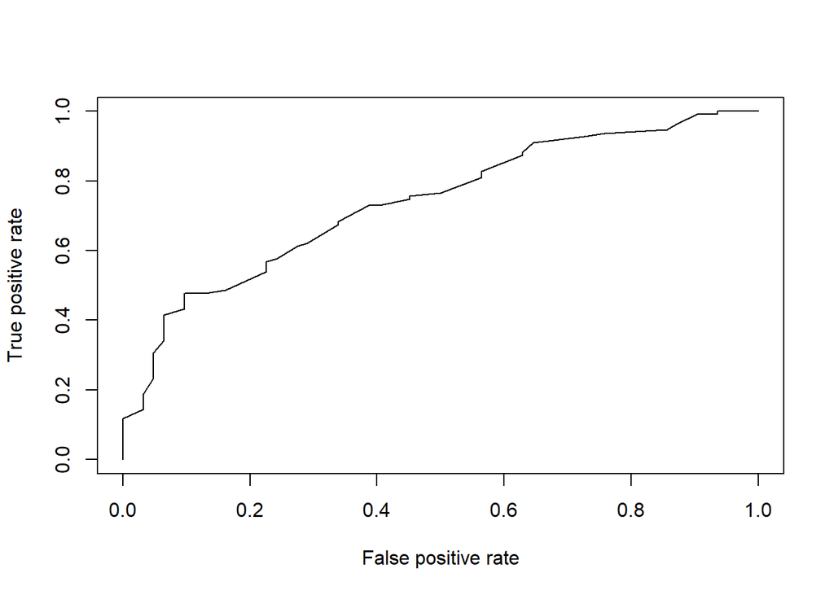

```r
pred <- prediction(fitted(fit),y)
perf <- performance(pred,"tpr","fpr")
plot(perf)
```

```r
performance(pred,"auc")
```

```
## An object of class "performance"
## Slot "x.name":
## [1] "None"
##
## Slot "y.name":
## [1] "Area under the ROC curve"
##
## Slot "alpha.name":
## [1] "none"
##
## Slot "x.values":
## list()
##
## Slot "y.values":
## [[1]]
## [1] 0.7379396
##
##
## Slot "alpha.values":
## list()
```

ROC curve and the area under it is 0.7379.

3. (3 points)

```r
hoslem.test(y,fitted(fit))
```

```
##
##  Hosmer and Lemeshow goodness of fit (GOF) test
##
## data:  y, fitted(fit)
## X-squared = 7.8334, df = 8, p-value = 0.4499
```

Hosmer–Lemeshow statistic=7.8334, and p-value=0.4499. Therefore this model fits well.

4. (4 points)

```r
x <- horseshoecrabs$Weight
x2 <- x^2
fit.1 <- glm(y ~ x, family=binomial(link=logit))
fit.2 <- glm(y ~ x+x2, family=binomial(link=logit))
summary(fit.1)
```

```
##
## Call:
## glm(formula = y ~ x, family = binomial(link = logit))
##
## Deviance Residuals:
##     Min       1Q   Median       3Q      Max
## -2.1108  -1.0749   0.5426   0.9122   1.6285
##
## Coefficients:
##             Estimate Std. Error z value Pr(>|z|)
## (Intercept)  -3.6947     0.8802  -4.198 2.70e-05 ***
## x             1.8151     0.3767   4.819 1.45e-06 ***
## ---
## Signif. codes:  0 '***' 0.001 '**' 0.01 '*' 0.05 '.' 0.1 ' ' 1
##
## (Dispersion parameter for binomial family taken to be 1)
##
##     Null deviance: 225.76  on 172  degrees of freedom
## Residual deviance: 195.74  on 171  degrees of freedom
## AIC: 199.74
##
## Number of Fisher Scoring iterations: 4
```

```r
summary(fit.2)
```

```
##
## Call:
## glm(formula = y ~ x + x2, family = binomial(link = logit))
##
## Deviance Residuals:
##     Min       1Q   Median       3Q      Max
## -2.1825  -1.0739   0.5197   0.9391   1.5430
##
## Coefficients:
##             Estimate Std. Error z value Pr(>|z|)
## (Intercept)  -1.8877     3.5492  -0.532    0.595
## x             0.2182     3.0816   0.071    0.944
## x2            0.3393     0.6543   0.519    0.604
##
## (Dispersion parameter for binomial family taken to be 1)
##
##     Null deviance: 225.76  on 172  degrees of freedom
## Residual deviance: 195.46  on 170  degrees of freedom
## AIC: 201.46
##
## Number of Fisher Scoring iterations: 5
```

According to the results, we could see that the model with x and x2 is not well, because all the parameters are not significant.

5. (4 points)  
   AIC for model 1 is 199.74 and for model 2 is 201.46, so we choose model 1(only have x) .

> Problem 5.18 (15 points)
1. (5 points)  
   This problem is similar with the example in 5.2.2. There are 8 cities, so we should put 7 dummy variables in this model. With intercept and Smoking, there are 9 variables.

```r
data('smokinglungcancer')
ftable(LungCancer ~ City + Smoking, data=smokinglungcancer)
```

```
##                   LungCancer Yes  No
## City      Smoking
## Beijing   Yes                126 100
##           No                  35  61
## Shanghai  Yes                908 688
##           No                 497 807
## Shenyang  Yes                913 747
##           No                 336 598
## Nanjing   Yes                235 172
##           No                  58 121
## Harbin    Yes                402 308
##           No                 121 215
## Zhengzhou Yes                182 156
##           No                  72  98
## Taiyuan   Yes                 60  99
##           No                  11  43
## Nanchang  Yes                104  89
##           No                  21  36
```

```r
slc=as.data.frame(smokinglungcancer)
slc=dcast(slc, City + Smoking ~ LungCancer)
slc=transform(slc, Smoking = relevel(Smoking, "No"))
fit=glm(cbind(Yes,No) ~ City + Smoking, family=binomial, data=slc)
summary(fit)
```

```
##
## Call:
## glm(formula = cbind(Yes, No) ~ City + Smoking, family = binomial,
##     data = slc)
##
## Deviance Residuals:
##      Min        1Q    Median        3Q       Max
## -1.21781  -0.14842  -0.00012   0.16817   1.35470
##
## Coefficients:
##                Estimate Std. Error z value Pr(>|z|)
## (Intercept)   -0.548682   0.118022  -4.649 3.34e-06 ***
## CityShanghai   0.055618   0.119570   0.465    0.642
## CityShenyang  -0.027739   0.120071  -0.231    0.817
## CityNanjing    0.005764   0.140911   0.041    0.967
## CityHarbin     0.018187   0.129473   0.140    0.888
## CityZhengzhou  0.028782   0.144755   0.199    0.842
## CityTaiyuan   -0.745683   0.185519  -4.019 5.83e-05 ***
## CityNanchang  -0.054906   0.170996  -0.321    0.748
## SmokingYes     0.777062   0.046775  16.613  < 2e-16 ***
## ---
## Signif. codes:  0 '***' 0.001 '**' 0.01 '*' 0.05 '.' 0.1 ' ' 1
##
## (Dispersion parameter for binomial family taken to be 1)
##
##     Null deviance: 310.8951  on 15  degrees of freedom
## Residual deviance:   5.1958  on  7  degrees of freedom
## AIC: 121.05
##
## Number of Fisher Scoring iterations: 3
```

$logit(\hat \pi)=-0.5487+0.0556\times SH-0.0277\times SY+0.0058\times NJ+0.0182\times HEB+0.0288\times ZZ-0.7457\times TY-0.0549\times NC+0.7771\times Smoking$.  
We could see that the variable “Smoking” is significant and positive, that means smoking will increase the probability of getting lung cancer.

2. (5 points)

```r
pearson.resid=resid(fit, type="pearson")
X2=sum(pearson.resid^2)
```

Using R, we could get Pearson statistics X2=5.200 and the p-value is more than 0.05, so this model fits well.

3. (5 points)

```r
std.resid=pearson.resid/sqrt(1-lm.influence(fit)$hat)
std.resid
```

```
##            1            2            3            4            5
##  0.038863100 -0.038863101 -0.247142035  0.247142036  0.001263846
##            6            7            8            9           10
## -0.001263846  1.483800386 -1.483800419  0.500221992 -0.500221996
##           11           12           13           14           15
## -1.711678487  1.711678519  0.229556858 -0.229556864 -0.268376554
##           16
##  0.268376557
```

Using R, we could get standardized residuals for each cell. So all absolute value smaller than roughly 2 or 3 provides evidence of good fit.

> Problem 5.22 (15 points)
1. (3 points) Since all observations such that y = 1 are on one side of the plane, all observations of y = 0 are on the other side of the plane,that is,they are perfectly seperated.When the value of the predictor is known, the result can be perfectly predicted,so the ML estimation is infinite.
2. (4 points)

```r
x=c(10,20,30,40,60,70,80,90)
y=c(rep(0,4),rep(1,4))
fit1=glm(y~x,family=binomial(link='logit'))
summary(fit1)
```

```
##
## Call:
## glm(formula = y ~ x, family = binomial(link = "logit"))
##
## Deviance Residuals:
##        Min          1Q      Median          3Q         Max
## -1.045e-05  -2.110e-08   0.000e+00   2.110e-08   1.045e-05
##
## Coefficients:
##               Estimate Std. Error z value Pr(>|z|)
## (Intercept)   -118.158 296046.187       0        1
## x                2.363   5805.939       0        1
##
## (Dispersion parameter for binomial family taken to be 1)
##
##     Null deviance: 1.1090e+01  on 7  degrees of freedom
## Residual deviance: 2.1827e-10  on 6  degrees of freedom
## AIC: 4
##
## Number of Fisher Scoring iterations: 25
```

From the result,$\hat \beta=2.363,SE=5805.939$.

3. (4 points)

```r
x=c(10,20,30,40,50,50,60,70,80,90)
y=c(rep(0,5),rep(1,5))
fit2=glm(y~x,family=binomial(link='logit'))
summary(fit2)
```

```
##
## Call:
## glm(formula = y ~ x, family = binomial(link = "logit"))
##
## Deviance Residuals:
##    Min      1Q  Median      3Q     Max
## -1.177   0.000   0.000   0.000   1.177
##
## Coefficients:
##              Estimate Std. Error z value Pr(>|z|)
## (Intercept)   -98.158  39288.592  -0.002    0.998
## x               1.963    785.772   0.002    0.998
##
## (Dispersion parameter for binomial family taken to be 1)
##
##     Null deviance: 13.8629  on 9  degrees of freedom
## Residual deviance:  2.7726  on 8  degrees of freedom
## AIC: 6.7726
##
## Number of Fisher Scoring iterations: 21
```

When the new samples are added,the results are still incorrect due to small estimation with large SE.

4. (4 points)

```r
x=c(10,20,30,40,50.1,49.9,60,70,80,90)
y=c(rep(0,5),rep(1,5))
fit3=glm(y~x,family=binomial(link='logit'))
summary(fit3)
```

```
##
## Call:
## glm(formula = y ~ x, family = binomial(link = "logit"))
##
## Deviance Residuals:
##      Min        1Q    Median        3Q       Max
## -1.19990  -0.00554   0.00000   0.00554   1.19990
##
## Coefficients:
##             Estimate Std. Error z value Pr(>|z|)
## (Intercept) -26.3874    49.0989  -0.537    0.591
## x             0.5277     0.9816   0.538    0.591
##
## (Dispersion parameter for binomial family taken to be 1)
##
##     Null deviance: 13.863  on 9  degrees of freedom
## Residual deviance:  2.900  on 8  degrees of freedom
## AIC: 6.9
##
## Number of Fisher Scoring iterations: 10
```